# EX3 (2)

### **about the competition:**

The competition is simple: use machine learning to create a model that predicts which passengers survived the Titanic shipwreck.

The sinking of the Titanic is one of the most infamous shipwrecks in history.

On April 15, 1912, during her maiden voyage, the widely considered “unsinkable” RMS Titanic sank after colliding with an iceberg. Unfortunately, there weren’t enough lifeboats for everyone onboard, resulting in the death of 1502 out of 2224 passengers and crew.

While there was some element of luck involved in surviving, it seems some groups of people were more likely to survive than others.

In this challenge, I will try to answer the question: “what sorts of people were more likely to survive?” using passenger data (ie name, age, gender, socio-economic class, etc).

[figure not shown]

In our assignment we will try to identify types of characteristics that can help us understand what the identity of the people who survived and those who did not survive looks like.

In order to answer the central question, we have like properties in the data that we will use:

survival Survival 0 = No, 1 = Yes

- Survival: 0 = No, 1 = Yes ------ the target
- Pclass: 1 = 1st, 2 = 2nd, 3 = 3rd
- Sex: Male or Female
- Ticket: Ticket number
- Fare: Passenger fare
- Cabin: Cabin number
- Embarked: Port of Embarkation

```python
!mkdir ~/.kaggle
!cp /content/drive/MyDrive/kaggle.json ~/.kaggle/kaggle.json
!kaggle competitions download -c titanic
```

```
mkdir: cannot create directory ‘/root/.kaggle’: File exists
Warning: Looks like you're using an outdated API Version, please consider updating (server 1.5.10 / client 1.5.4)
train.csv: Skipping, found more recently modified local copy (use --force to force download)
gender_submission.csv: Skipping, found more recently modified local copy (use --force to force download)
test.csv: Skipping, found more recently modified local copy (use --force to force download)
```

# imports

```python
import pandas as pd
import numpy as np
import sklearn
from sklearn.model_selection import train_test_split
from sklearn import metrics
from sklearn.preprocessing import LabelEncoder,PolynomialFeatures,Normalizer,StandardScaler,MinMaxScaler,PolynomialFeatures,OneHotEncoder
from sklearn import pipeline
# for visualization
import seaborn as sns
import matplotlib.pyplot as plt
import plotly.graph_objects as go
from sklearn.compose import ColumnTransformer

from sklearn.metrics import plot_confusion_matrix
from sklearn.linear_model import LogisticRegression, SGDClassifier
from sklearn.neural_network import MLPClassifier
from sklearn.neighbors import KNeighborsClassifier
from sklearn.linear_model import Lasso
from sklearn.metrics import mean_squared_error,classification_report,r2_score,log_loss

import matplotlib.pyplot as plt
import seaborn as sns
from sklearn.model_selection import cross_val_score

from sklearn.model_selection import StratifiedShuffleSplit
from sklearn.metrics import accuracy_score, log_loss
from sklearn.neighbors import KNeighborsClassifier,KNeighborsRegressor
from sklearn.svm import SVC,SVR
from sklearn.tree import DecisionTreeClassifier,DecisionTreeRegressor,ExtraTreeRegressor
from sklearn.ensemble import RandomForestClassifier, AdaBoostClassifier, GradientBoostingClassifier,AdaBoostRegressor
from sklearn.ensemble import BaggingRegressor,GradientBoostingRegressor,StackingRegressor,VotingRegressor,RandomForestClassifier
from sklearn.naive_bayes import GaussianNB
from sklearn.discriminant_analysis import LinearDiscriminantAnalysis, QuadraticDiscriminantAnalysis
from sklearn.linear_model import LogisticRegression,LinearRegression,Ridge,SGDRegressor,RANSACRegressor
```

# Read train file and separate y_Survived column

```python
train = pd.read_csv('train.csv')
test = pd.read_csv('test.csv')
train_cpy = train.copy()
test_cpy = train.copy()

y_Survived = train.Survived
train.drop('Survived',axis=1,inplace=True)
```

## We can see that there is almost no information about the cabin column (77 percent is missing) so we will give it up for good results

```
The percentage of missing information in the Cabin column is 0.7710437710437711
```

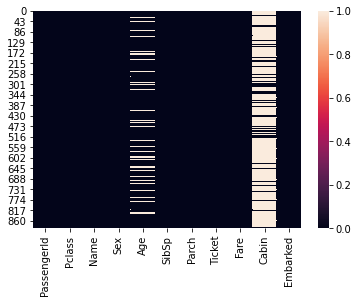

```python
print('The percentage of missing information in the Cabin column is',train.Cabin.isnull().sum()/len(train))
sns.heatmap(train.isnull())
plt.show()
```

lets look on missing data

```python
#on training srt
```

```python
train.isnull().sum()
```

```
PassengerId      0
Pclass           0
Name             0
Sex              0
Age            177
SibSp            0
Parch            0
Ticket           0
Fare             0
Cabin          687
Embarked         2
dtype: int64
```

```python
#on test set
```

```python
test.isnull().sum()
```

```
PassengerId      0
Pclass           0
Name             0
Sex              0
Age             86
SibSp            0
Parch            0
Ticket           0
Fare             1
Cabin          327
Embarked         0
dtype: int64
```

```python
#fill Fare & Embarked
```

```python
test.Fare.fillna(test.Fare.mean(),inplace=True)
train.Embarked.fillna(train['Embarked'].value_counts().head(1).index[0],inplace=True)
```

decied to remove Ticket col

```python
train.Ticket.value_counts()
```

```
1601        7
347082      7
CA. 2343    7
3101295     6
CA 2144     6
           ..
28206       1
350046      1
2674        1
113773      1
364506      1
Name: Ticket, Length: 681, dtype: int64
```

```python
train.drop('Ticket',axis=1,inplace=True)
test.drop('Ticket',axis=1,inplace=True)
```

# Name - Take care of the title of the name - will be easier to do this column labeled

```python
train.Name = train_cpy['Name'].str.split(',', expand=True)[1].str.split('.',expand=True)[0].str.strip()
test.Name = test_cpy['Name'].str.split(',', expand=True)[1].str.split('.',expand=True)[0].str.strip()
```

```python
train.dtypes[train.dtypes == 'object']
```

```
Name        object
Sex         object
Cabin       object
Embarked    object
dtype: object
```

Labeled Sex col - Label encoding

```python
lb = LabelEncoder().fit(train.Sex)
train.Sex = lb.transform(train.Sex)
test.Sex = lb.transform(test.Sex)
```

function for labeled features - Onehotencoding

```python
def labeled(col,train=train,test=test):
  enc = OneHotEncoder(handle_unknown='ignore')
  train_ON = pd.DataFrame(enc.fit_transform(train[[col]]).toarray(),columns=pd.get_dummies(train[col],prefix=col).columns)
  test_ON = pd.DataFrame(enc.transform(test[[col]]).toarray(),columns=train_ON.columns)

  train = train.join(train_ON)
  test = test.join(train_ON)
  return train,test

train,test=labeled('Name')
train,test=labeled('Embarked',train,test)
```

```python
feature_label = ['Name','Embarked']
train.drop(feature_label,axis=1,inplace=True)
test.drop(feature_label,axis=1,inplace=True)
```

check null in test

```python
test.isnull().sum()[test.isnull().sum() > 0]
```

```
Age       86
Cabin    327
dtype: int64
```

check null in train

```python
train.isnull().sum()[train.isnull().sum() > 0]
```

```
Age      177
Cabin    687
dtype: int64
```

take the cabin label

```python
train.Cabin = train.Cabin.str[0]
test.Cabin = test.Cabin.str[0]
```

```python
#fill age
```

### Find the best model for filling in the missing data

```python
corr_val = 0.1

reggresors = [KNeighborsRegressor(),ExtraTreeRegressor(random_state=1),DecisionTreeRegressor(random_state=1, max_features='auto'),BaggingRegressor(random_state=1),GradientBoostingRegressor(random_state=1),Lasso(random_state=1),LinearRegression(),Ridge(random_state=1),SGDRegressor(random_state=1),RANSACRegressor(random_state=1),SVR(),AdaBoostRegressor(random_state=1)]
```

|  | Regressor | MSE train | MSE test |
| --- | --- | --- | --- |
| 0 | KNeighborsRegressor | 115.182319 | 169.387992 |
| 1 | ExtraTreeRegressor | 55.467632 | 217.145090 |
| 2 | DecisionTreeRegressor | 55.467632 | 208.864380 |
| 3 | BaggingRegressor | 71.629860 | 166.575537 |
| 4 | GradientBoostingRegressor | 100.421591 | 127.951784 |
| 5 | Lasso | 153.545965 | 177.566172 |
| 6 | LinearRegression | 143.666749 | 153.833307 |
| 7 | Ridge | 143.668610 | 153.904713 |
| 8 | SGDRegressor | 143.760698 | 153.986590 |
| 9 | RANSACRegressor | 190.683106 | 232.660268 |
| 10 | SVR | 153.693438 | 178.448944 |
| 11 | AdaBoostRegressor | 144.261392 | 159.385628 |
| 12 | MEAN | 205.273409 | 259.320935 |
| 13 | MEDIAN | 208.718400 | 257.232519 |

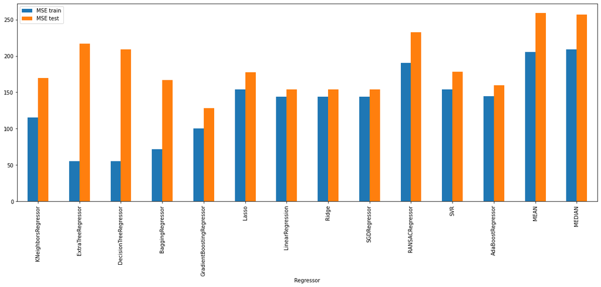

```python
age_full = train[train.Age.isna() == False].drop(['Cabin'],axis=1)
X = age_full.drop(['Age'],axis=1)

sd = StandardScaler()
X = pd.DataFrame(sd.fit_transform(X),columns=X.columns)[age_full.drop('Age',axis=1).corrwith(y_Survived)[abs(age_full.drop('Age',axis=1).corrwith(y_Survived))>corr_val].index]
columns_X = X.columns

y = age_full.Age
X_train, X_test, y_train, y_test = train_test_split(X, y, test_size=0.1, random_state=101)

df_age_statics = pd.DataFrame(columns=['Regressor','MSE train','MSE test'])

for model in reggresors:
  model = model.fit(X_train, y_train)
  preds = model.predict(X_test)
  error_train = mean_squared_error(model.predict(X_train),y_train)
  error_test = mean_squared_error(y_test,preds)
  df_age_statics = df_age_statics.append({'Regressor':str(model).split('(')[0],'MSE train':error_train,'MSE test':error_test},ignore_index=True)
df_age_statics = df_age_statics.append({'Regressor':'MEAN','MSE train':mean_squared_error(np.ones(len(y_train))*train.Age.mean(),y_train),'MSE test':mean_squared_error(np.ones(len(y_test))*train.Age.mean(),y_test)},ignore_index=True)
df_age_statics = df_age_statics.append({'Regressor':'MEDIAN','MSE train':mean_squared_error(np.ones(len(y_train))*train.Age.median(),y_train),'MSE test':mean_squared_error(np.ones(len(y_test))*train.Age.median(),y_test)},ignore_index=True)

df_age_statics.plot(x='Regressor',y=['MSE train','MSE test'],kind='bar',figsize=(20,7))
df_age_statics
```

```python
#set the results with the best model
```

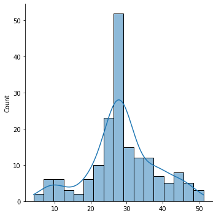

```python
age_null = train[train.Age.isna()].drop(['Age','Cabin'],axis=1)
age_null = pd.DataFrame(sd.transform(age_null),columns=age_null.columns)[age_full.drop('Age',1).columns]
age_null = age_null[columns_X]
model = GradientBoostingRegressor().fit(X_train, y_train)
results = model.predict(age_null)
sns.displot(results,kde=True)
```

```python
train.Age[train.Age.isna()] = results
```

```python
age_null = test[test.Age.isna()].drop(['Age','Cabin'],axis=1)

age_null = pd.DataFrame(sd.transform(age_null),columns=age_null.columns)[columns_X]
results = model.predict(age_null)
results = np.where(results > 0, results, 0)
test.Age[test.Age.isna()] = results
```

```python
test.isna().sum()[test.isna().sum() > 0]
```

```
Cabin    327
dtype: int64
```

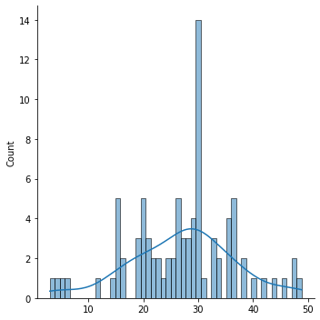

```python
sns.displot(results,bins=50,kde=True)
```